# Workshop | Intro to Data Analysis with Python

**Welcome back!**

In the last two workshops, we had talked about Python basics, and we are going to finally use it for data analysis here! (Yeah!!!)

Please feel free to refer to material from the last 2 workshops:

[Workshop I](https://drive.google.com/drive/folders/1jmyLce8YQIvU0Mwb-r1PlFJd7YjDpLRo) : Intro to Python

- Comments, Variables, Operators, Statements

[Workshop II](https://drive.google.com/drive/folders/1xBt2kX4ia9Uah4Q8Im1IlUWOnTtTO5Zl) : Intro to Data Structures

- Data Collections including Lists, Tuples, Sets, and Dictionaries
- Iterations including while loop and for loop
- Writing functions

## **Getting Started**

**Workshop Best Practices**

- If you want to take notes, it is recommended to make a copy of this notebook via this [link](https://colab.research.google.com/drive/1j_vVoJjifmNNgVVqu-pFbKekjryklUKi?usp=sharing) ('File' - 'Save a Copy in Drive') and open it via Google Colab.
- Make sure your notebook is connected.

[figure not shown]

- This will be a live coding session. Feel free to edit the code on your copy.
- **How to run**? Click on the little arrow besides each chunk of code, or click on 'Runtime' - 'Run Selection'.
  - Run the code chunk-by-chunk, don't run all at once.
  - Some codes are dependent on previous codes, if you hit an error, check if you have ran the previous codes.
- If you feel the pace is too fast, please let the instructor know. Otherwise, save your questions till the end of each section.

## **Task 0: Installing Python Packages**

Data Cleaning / Data Manipulation:

- NumPy
- Pandas

Data Visualization:

- Matplotlib

```python
# import packages
import numpy as np
import pandas as pd
import matplotlib.pyplot as plt
%matplotlib inline
# directly shows graph without plt.show()
```

## Task 1: Understanding N-Dimensional Arrays (ndarray)

### Recap: Previous Data Types

1. Workshop 1

| Basic Data Types | Example | Meaning/ Usage |
| --- | --- | --- |
| Integer (int) | 1, 2, 3 | Integer numbers |
| String (str) | "apple" | Text |
| Float (float) | 5.55 | Floating/ decimal point numbers |
| Boolean (bool) | True, False | True/False (Boolean) values |

1. Workshop 2

| Collection Data Types | Example | Properties |
| --- | --- | --- |
| List (list) | ["apple", "orange", 5] | Changeable, Ordered, Duplicate allowed |
| Tuple (tuple) | ("apple", "orange", 5) | Unchangeable, Ordered, Duplicate allowed |
| Set (set) | {"apple", "orange", 5} | Unchangeable, Unordered, No duplicates |
| Dictionary (dict) | {"apple": 5, "orange": 10} | Key:Value pairs, Unchangeable, Unordered, No duplicates |

### New Data Type: Arrays

- Like lists, an *array* can also store a collection of items with the similar properties -- **ordered**, **mutable**, able to store **duplicates**.
- Python does not have arrays by default. You have to import the Array module or NumPy package to use them.

**Array module** ([documentation](https://docs.python.org/3/library/array.html))

- Standard Python module with basic, specific functions.
- Need to specify the type code when declaring the array, and only 1 data type could be stored in the array ([list of commonly used type codes](https://www.programiz.com/python-programming/array))

```
    import array as arr
    # first arg: type code, which specifies the data type in the array to be integer
    array_1 = arr.array('i',[3, 6, 9, 12])
```

**NumPy package** ([documentation](https://numpy.org/doc/stable/) | what we'll use today)

- NumPy is the fundamental package for **scientific computing** in Python.
- Arrays support different data types, so that you only need to specify the items, not the types of the items

```
    import numpy as np
    array_2 = np.array(['one', 2, 3, 4])
```

### Use NumPy to Create N-Dimensional Arrays (ndarrays)

NumPy is a Python library that importantly provides a multidimensional array object, various derived objects (such as masked arrays and matrices), and an assortment of routines for fast operations on arrays, including mathematical, logical, shape manipulation, sorting, selecting, I/O, discrete Fourier transforms, basic linear algebra, basic statistical operations, random simulation and much more.

NumPy’s array class is called **ndarray**. Ndarray is also the main object in the NumPy library.

- It is a table of elements (usually numbers), all of the same type, indexed by a tuple of non-negative integers.
- Again, numpy.array (shorthand: np.array) is not the same as the Standard Python Library class array.array (shorthand: arr.array), which only handles one-dimensional arrays and offers less functionality.

```python
a = np.array(['one', 2, 3, 4])
print(type(a))
```

```
<class 'numpy.ndarray'>
```

#### Array Creation & Properties

There are several ways to create arrays.

For example, you can create an array from a regular Python list or tuple using the np.array function. The type of the resulting array is deduced from the type of the elements in the sequences.

Below are some other important attributes of an ndarray object:

1. **ndarray.ndim**
- the number of axes (dimensions) of the array.
- In NumPy dimensions are called axes.
1. **ndarray.shape**
- the dimensions of the array. This is a tuple of integers indicating the size of the array in each dimension. For a matrix with n rows and m columns, shape will be (n,m). The length of the shape tuple is therefore the number of axes, ndim.
1. **ndarray.size**
- the total number of elements of the array. This is equal to the product of the elements of shape.
1. **ndarray.dtype**
- an object describing the type of the elements in the array. One can create or specify dtype’s using standard Python types. Additionally NumPy provides types of its own. numpy.int32, numpy.int16, and numpy.float64 are some examples.

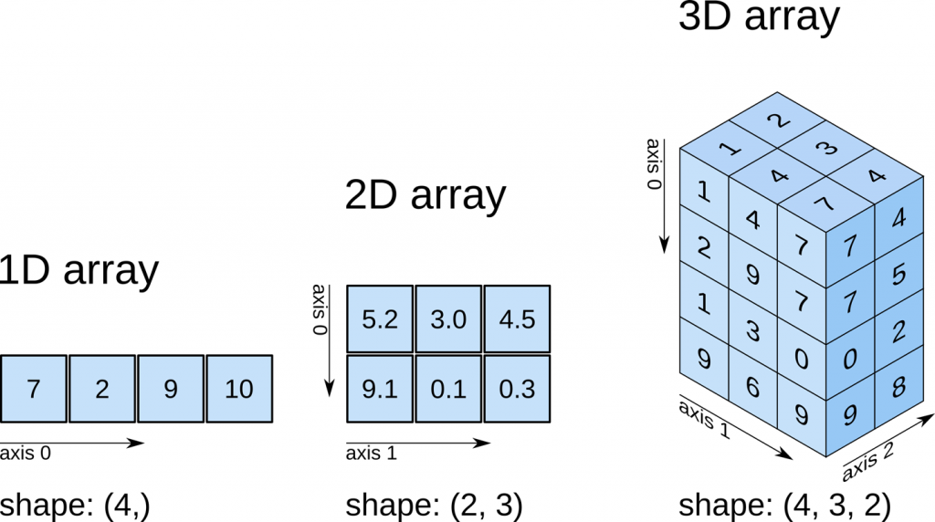

We can only see/ perceive up to 3 dimensions, but NumPy **ndarrays** allows us to deal with data with many more dimensions.

**1-D Arrays**

```python
# homogenous
a = np.array([2, 3, 4])
print(a)
print("Number of axes (dimensions) of a: ", a.ndim)
print("Dimensionlity of a (if there is only 1 row, the output will ignore it): ", a.shape)
print("Number of elements in a: ", a.size)
print("Data type in a: ", a.dtype)
```

```
[2 3 4]
Number of axes (dimensions) of a:  1
Dimensionlity of a (if there is only 1 row, the output will ignore it):  (3,)
Number of elements in a:  3
Data type in a:  int64
```

```python
# mixed
b = np.array([1.2, 3.5, "blue"])
print("Number of axes (dimensions) of b: ", b.ndim)
print("Dimensionlity of b (if there is only 1 row, the output will ignore it): ", b.shape)
print("Number of elements in b: ", b.size)
print("Data types in b: ", b.dtype) # mixed data type in an array
```

```
Number of axes (dimensions) of b:  1
Dimensionlity of b (if there is only 1 row, the output will ignore it):  (3,)
Number of elements in b:  3
Data types in b:  <U32
```

Read more about what **<U32** means [here](https://stackoverflow.com/questions/56944812/how-to-interpret-python-output-dtype-u32).

**2-D Arrays**

```python
#homogenous
c = np.array([(1.5, 2, 3),
              (4, 5, 6)])
print(c)
print("Number of axes (dimensions) of c: ", c.ndim)
print("Dimensionlity of c: ", c.shape)
print("Number of elements in c: ", c.size)
print("Data type in c: ", c.dtype)
```

```
[[1.5 2.  3. ]
 [4.  5.  6. ]]
Number of axes (dimensions) of c:  2
Dimensionlity of c:  (2, 3)
Number of elements in c:  6
Data type in c:  float64
```

```python
# specify the type to complex number
d = np.array([[1, 2],
              [3, 4]],
              dtype = complex)
print(d)
print("Number of axes (dimensions) of c: ", d.ndim)
print("Dimensionlity of c (row x col): ", d.shape)
```

```
[[1.+0.j 2.+0.j]
 [3.+0.j 4.+0.j]]
Number of axes (dimensions) of c:  2
Dimensionlity of c (row x col):  (2, 2)
```

```python
# if you are want to create n-D arrays (n>1) with mixed data type
# you must specify the dtype to "object"
e = np.array([["hi",1,2,3],
              ["bye",4,5,6]],
              dtype = object)
```

**PRACTICE: What is the number of axes, dimensionality, and number of elements in e?**

```python
# Write your code here!
```

Often, the elements of an array are originally unknown, but its size is known. Hence, NumPy offers several functions to create arrays with initial placeholder content. These minimize the necessity of growing arrays, an expensive operation.

The function **zeros** creates an array full of zeros, the function **ones** creates an array full of ones, and the function **empty** creates an array whose initial content is random and depends on the state of the memory. By default, the dtype of the created array is float64, but it can be specified via the key word argument dtype.

```python
np.zeros((3, 4))
```

```
array([[0., 0., 0., 0.],
       [0., 0., 0., 0.],
       [0., 0., 0., 0.]])
```

```python
np.ones((2, 3, 4), dtype = np.int16)
```

```
array([[[1, 1, 1, 1],
        [1, 1, 1, 1],
        [1, 1, 1, 1]],

       [[1, 1, 1, 1],
        [1, 1, 1, 1],
        [1, 1, 1, 1]]], dtype=int16)
```

```python
np.empty((2, 3))
```

```
array([[0.e+000, 0.e+000, 5.e-324],
       [0.e+000, 0.e+000, 5.e-324]])
```

To create sequences of numbers, NumPy provides the arange function which is analogous to the Python built-in range, but returns an array.

```python
# np.arange(start, end, increment)
# the end position is always not included
np.arange(10, 31, 5)
```

```
array([10, 15, 20, 25, 30])
```

```python
np.arange(0, 2, 0.3)  # it accepts float arguments
```

```
array([0. , 0.3, 0.6, 0.9, 1.2, 1.5, 1.8])
```

**PRACTICE: Create an array that starts from 0 and end at 100 (including), incrementing by 10**

```python
# (you should end up with the output below)
```

```
array([  0,  10,  20,  30,  40,  50,  60,  70,  80,  90, 100])
```

#### Basic Operations

Arithmetic operators on arrays apply elementwise. A new array is created and filled with the result.

```python
a = np.array([20, 30, 40, 50])
print(a)
b = np.arange(4)
print(b)
c = a - b
print(c)
```

```
[20 30 40 50]
[0 1 2 3]
[20 29 38 47]
```

```python
# squaring
b = np.arange(4)
print(b)
b**2
```

```
[0 1 2 3]
```

```
array([0, 1, 4, 9])
```

```python
# sin functions
10 * np.sin(a)
```

```
array([ 9.12945251, -9.88031624,  7.4511316 , -2.62374854])
```

```python
# run a logical statement through an array
a < 35
```

```
array([ True,  True, False, False])
```

## **Task 2: From ndarray in NumPy to Pandas DataFrame**

Now that we have learned about NumPy ndarrays, let's pivot into Pandas DataFrames, which builds on ndarrays.

In this task, we are going to work with a dataset of cars.

### Reading / Writing Dataset

Datasets are commonly stored as CSV files or Excel files.

3 Ways to Load CSV files into Colab: https://towardsdatascience.com/3-ways-to-load-csv-files-into-colab-7c14fcbdcb92

Step 1: **Import** the library, authenticate, and create the interface to csv files.

```python
# Mount the Google Drive to your computer
from google.colab import drive
drive.mount('/content/drive')
```

```python
!pip install -U -q PyDrive
from pydrive.auth import GoogleAuth
from pydrive.drive import GoogleDrive
from google.colab import auth
from oauth2client.client import GoogleCredentials

# Authenticate and create the PyDrive client.
# Connect to Google Cloud SDK
# Tools and libraries for interacting with Google Cloud products and services.
auth.authenticate_user()
gauth = GoogleAuth()
gauth.credentials = GoogleCredentials.get_application_default()
drive = GoogleDrive(gauth)
```

Step 2: Import the data from csv file as a Pandas DataFrame object

*When working with your own csv file stored on Google drive, you simply need to get the sharable link and substitute the link.

**Also, rename myfile to the file name of your choice.

```python
# The shareable link to our csv file,
# "https://drive.google.com/file/d/1PTzHOzz_ecK0aeyn2ZyCBG-S8IyrqUsr/view?usp=sharing"
id = "1PTzHOzz_ecK0aeyn2ZyCBG-S8IyrqUsr"
downloaded = drive.CreateFile({'id': id})
downloaded.GetContentFile('cars.csv')
```

```python
cars = pd.read_csv('cars.csv') # --> reads the csv, turns it into Pandas DataFrame
# for full DataFrame
# cars
```

```python
# for first 5 rows in the DataFrame
cars.head()
```

|  | YEAR | Make | Model | Size | (kW) | Unnamed: 5 | TYPE | CITY (kWh/100 km) | HWY (kWh/100 km) | COMB (kWh/100 km) | CITY (Le/100 km) | HWY (Le/100 km) | COMB (Le/100 km) | (g/km) | RATING | (km) | TIME (h) |
| --- | --- | --- | --- | --- | --- | --- | --- | --- | --- | --- | --- | --- | --- | --- | --- | --- | --- |
| 0 | 2012 | MITSUBISHI | i-MiEV | SUBCOMPACT | 49 | A1 | B | 16.9 | 21.4 | 18.7 | 1.9 | 2.4 | 2.1 | 0 | NaN | 100 | 7 |
| 1 | 2012 | NISSAN | LEAF | MID-SIZE | 80 | A1 | B | 19.3 | 23.0 | 21.1 | 2.2 | 2.6 | 2.4 | 0 | NaN | 117 | 7 |
| 2 | 2013 | FORD | FOCUS ELECTRIC | COMPACT | 107 | A1 | B | 19.0 | 21.1 | 20.0 | 2.1 | 2.4 | 2.2 | 0 | NaN | 122 | 4 |
| 3 | 2013 | MITSUBISHI | i-MiEV | SUBCOMPACT | 49 | A1 | B | 16.9 | 21.4 | 18.7 | 1.9 | 2.4 | 2.1 | 0 | NaN | 100 | 7 |
| 4 | 2013 | NISSAN | LEAF | MID-SIZE | 80 | A1 | B | 19.3 | 23.0 | 21.1 | 2.2 | 2.6 | 2.4 | 0 | NaN | 117 | 7 |

```python
type(cars)
```

```
pandas.core.frame.DataFrame
```

### New Data Type: Pandas DataFrame

Pandas is a library that builds on NumPy, providing more functionality, especially for data science.

Pandas DataFrames ([documentation](https://pandas.pydata.org/docs/reference/api/pandas.DataFrame.html?highlight=dataframe#pandas.DataFrame)) are two-dimensional, size-mutable, potentially heterogeneous **tabular** data.

#### Data Parameter: ndarray, and more

- data: ndarray (structured or homogeneous), Iterable, dict, or DataFrame

  Dict can contain Series, arrays, constants, dataclass or list-like objects. If data is a dict, column order follows insertion-order.
  - Changed in version 0.25.0: If data is a list of dicts, column order follows insertion-order.
- index: Index or array-like

  Index to use for resulting frame. Will default to RangeIndex if no indexing information part of input data and no index provided.
- columns: Index or array-like

  Column labels to use for resulting frame when data does not have them, defaulting to RangeIndex(0, 1, 2, …, n). If data contains column labels, will perform column selection instead.
- dtype: dtype, default None Data type to force. Only a single dtype is allowed. If None, infer.
- copy: bool or None, default None Copy data from inputs. For dict data, the default of None behaves like copy=True. For DataFrame or 2d ndarray input, the default of None behaves like copy=False.
  - Changed in version 1.3.0.

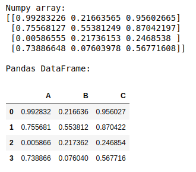

#### Change a np.array into pd.DataFrame

```python
array1 = np.array([["Fruit","Cost","Number of Items"],
                   ["Apple",1,5],
                   ["Pear",2,6],
                   ["Berry",3,7]])
print(array1)
```

```
[['Fruit' 'Cost' 'Number of Items']
 ['Apple' '1' '5']
 ['Pear' '2' '6']
 ['Berry' '3' '7']]
```

```python
# make array into table-like dataframe with the pd.DataFrame() constructor
df = pd.DataFrame(array1)
print(df)
```

```
       0     1                2
0  Fruit  Cost  Number of Items
1  Apple     1                5
2   Pear     2                6
3  Berry     3                7
```

```python
# change first row into column name
df.columns = df.iloc[0]
# drop the first row, so it won't appear twice
df = df[1:]
df
```

|  | Fruit | Cost | Number of Items |
| --- | --- | --- | --- |
| 1 | Apple | 1 | 5 |
| 2 | Pear | 2 | 6 |
| 3 | Berry | 3 | 7 |

### **Basic Data Manipulation**

To refresh your memory, our dataset has been transformed from a csv file into a pd.DataFrame, and its variable name is **cars**.

Now, let's take a look at the dataset!

```python
# .head() lets you look at the first 5 rows of the data by default
# but you can also pass in an arg to change the rows of data you want to view
cars.head()
```

|  | YEAR | Make | Model | Size | (kW) | Unnamed: 5 | TYPE | CITY (kWh/100 km) | HWY (kWh/100 km) | COMB (kWh/100 km) | CITY (Le/100 km) | HWY (Le/100 km) | COMB (Le/100 km) | (g/km) | RATING | (km) | TIME (h) |
| --- | --- | --- | --- | --- | --- | --- | --- | --- | --- | --- | --- | --- | --- | --- | --- | --- | --- |
| 0 | 2012 | MITSUBISHI | i-MiEV | SUBCOMPACT | 49 | A1 | B | 16.9 | 21.4 | 18.7 | 1.9 | 2.4 | 2.1 | 0 | NaN | 100 | 7 |
| 1 | 2012 | NISSAN | LEAF | MID-SIZE | 80 | A1 | B | 19.3 | 23.0 | 21.1 | 2.2 | 2.6 | 2.4 | 0 | NaN | 117 | 7 |
| 2 | 2013 | FORD | FOCUS ELECTRIC | COMPACT | 107 | A1 | B | 19.0 | 21.1 | 20.0 | 2.1 | 2.4 | 2.2 | 0 | NaN | 122 | 4 |
| 3 | 2013 | MITSUBISHI | i-MiEV | SUBCOMPACT | 49 | A1 | B | 16.9 | 21.4 | 18.7 | 1.9 | 2.4 | 2.1 | 0 | NaN | 100 | 7 |
| 4 | 2013 | NISSAN | LEAF | MID-SIZE | 80 | A1 | B | 19.3 | 23.0 | 21.1 | 2.2 | 2.6 | 2.4 | 0 | NaN | 117 | 7 |

#### Cleaning up Column Names

- Column names are ideally descriptive.
- Column names are case sensitive.

```python
# 1. Rename column "Make" into "Brands" for more clarity
cars = cars.rename({"Make":'Brands'}, axis=1)
# axis = 1 refers to the column names, whereas axis = 0 refers to the row indices

# 2. Unify all column names to capitalized words
cars.columns = cars.columns.str.capitalize()
cars.head()
```

|  | Year | Brands | Model | Size | (kw) | Unnamed: 5 | Type | City (kwh/100 km) | Hwy (kwh/100 km) | Comb (kwh/100 km) | City (le/100 km) | Hwy (le/100 km) | Comb (le/100 km) | (g/km) | Rating | (km) | Time (h) |
| --- | --- | --- | --- | --- | --- | --- | --- | --- | --- | --- | --- | --- | --- | --- | --- | --- | --- |
| 0 | 2012 | MITSUBISHI | i-MiEV | SUBCOMPACT | 49 | A1 | B | 16.9 | 21.4 | 18.7 | 1.9 | 2.4 | 2.1 | 0 | NaN | 100 | 7 |
| 1 | 2012 | NISSAN | LEAF | MID-SIZE | 80 | A1 | B | 19.3 | 23.0 | 21.1 | 2.2 | 2.6 | 2.4 | 0 | NaN | 117 | 7 |
| 2 | 2013 | FORD | FOCUS ELECTRIC | COMPACT | 107 | A1 | B | 19.0 | 21.1 | 20.0 | 2.1 | 2.4 | 2.2 | 0 | NaN | 122 | 4 |
| 3 | 2013 | MITSUBISHI | i-MiEV | SUBCOMPACT | 49 | A1 | B | 16.9 | 21.4 | 18.7 | 1.9 | 2.4 | 2.1 | 0 | NaN | 100 | 7 |
| 4 | 2013 | NISSAN | LEAF | MID-SIZE | 80 | A1 | B | 19.3 | 23.0 | 21.1 | 2.2 | 2.6 | 2.4 | 0 | NaN | 117 | 7 |

#### Data attributes

Carefully check the columns and rows. Understand what each column/row stands for. Each dataframe has several attributes. Exploring some of the attributes can help us quickly get to know the data. Here, the attributes are simply the properties of an object.

Some useful functions/methods

- Methods are associated with the objects of the class they belong to. Functions are not associated with any object.

| Function | Explanation |
| --- | --- |
| DataFrame.shape | Return a tuple representing the dimensionality of the DataFrame. |
| DataFrame.columns | returns the column names of the data |
| DataFrame.dtypes | returns the data type of each column |

When accessing an attribute for a dataframe, you can simply replace DataFrame using the name of your own data.

**Process is very similar to getting attributes of NumPy arrays**

```python
cars.columns = cars.columns.str.capitalize()
```

```python
#Tuple: (Rows, Columns)
cars.shape
```

```
(53, 17)
```

```python
cars.columns
```

```
Index(['Year', 'Brands', 'Model', 'Size', '(kw)', 'Unnamed: 5', 'Type',
       'City (kwh/100 km)', 'Hwy (kwh/100 km)', 'Comb (kwh/100 km)',
       'City (le/100 km)', 'Hwy (le/100 km)', 'Comb (le/100 km)', '(g/km)',
       'Rating', '(km)', 'Time (h)'],
      dtype='object')
```

```python
cars.dtypes
```

[output not shown]

The following table more clearly shows the common Pandas dtype and their corresponding Python Data Type

| Pandas dtype | Corresponding Python type | Usage |
| --- | --- | --- |
| object | str | Text |
| int64 | int | Integer numbers |
| float64 | float | Floating point numbers |
| bool | bool | True/False (Boolean) values |
| datetime64 | NA | Date and time values |
| category | NA | Finite list of text values |

- `int64` indicates that data in the column are integer numbers
- `float64` indicates that data in the column are float numbers
- `object` indicates that data in the column are strings
- `datetime64` is a date-and-time value, which is not a default Python data type, but could be useful in analytical work

#### Table Index and label

Each row and column in the dataframe has its own **index** and **label**

**Index (Numeral)**

(1) Indexing of a row

Each row has its unique index, starting from zero.

(2) Indexing of a column

Each column has its unique index, starting from zero as well.

**Label**

(1) Label of a row

each column has its unique label. It is given in the left-most column in bold font. Usually, it is the same as the index.

> `DataFrame.index` method returns the labels of the rows

(2) Label of a column

each column has its unique label. It is given in the first row of the spreadsheet.

> `DataFrame.columns` method returns the labels of the columns

```python
#print(cars)
print(cars.index) # index for the rows, numerals
print(cars.columns) # index for the columns, which are labels in text
```

[output not shown]

#### Get columns based on labels

We might be interested in keeping only certain columns.

The direct way is to use

`DataFrame[["column1","column3",...]]`

where "column1", "column3", etc are the labels of the columns you want to select.

Note: If you only used single brackets to get a column, we will get Pandas series. Pandas series is a one-dimensional data structure in Pandas. It is very similar to the list/array we have seen before. However, each element has its label.

```python
# lets get ONLY the 'Year' and 'Brands' information
cars[['Year','Brands']]
```

|  | Year | Brands |
| --- | --- | --- |
| 0 | 2012 | MITSUBISHI |
| 1 | 2012 | NISSAN |
| 2 | 2013 | FORD |
| 3 | 2013 | MITSUBISHI |
| 4 | 2013 | NISSAN |
| 5 | 2013 | SMART |
| 6 | 2013 | SMART |
| 7 | 2013 | TESLA |
| 8 | 2013 | TESLA |
| 9 | 2013 | TESLA |
| 10 | 2013 | TESLA |
| 11 | 2014 | CHEVROLET |
| 12 | 2014 | FORD |
| 13 | 2014 | MITSUBISHI |
| 14 | 2014 | NISSAN |
| 15 | 2014 | SMART |
| 16 | 2014 | SMART |
| 17 | 2014 | TESLA |
| 18 | 2014 | TESLA |
| 19 | 2014 | TESLA |
| 20 | 2015 | BMW |
| 21 | 2015 | CHEVROLET |
| 22 | 2015 | FORD |
| 23 | 2015 | KIA |
| 24 | 2015 | MITSUBISHI |
| 25 | 2015 | NISSAN |
| 26 | 2015 | SMART |
| 27 | 2015 | SMART |
| 28 | 2015 | TESLA |
| 29 | 2015 | TESLA |
| 30 | 2015 | TESLA |
| 31 | 2015 | TESLA |
| 32 | 2015 | TESLA |
| 33 | 2015 | TESLA |
| 34 | 2016 | BMW |
| 35 | 2016 | CHEVROLET |
| 36 | 2016 | FORD |
| 37 | 2016 | KIA |
| 38 | 2016 | MITSUBISHI |
| 39 | 2016 | NISSAN |
| 40 | 2016 | NISSAN |
| 41 | 2016 | SMART |
| 42 | 2016 | SMART |
| 43 | 2016 | TESLA |
| 44 | 2016 | TESLA |
| 45 | 2016 | TESLA |
| 46 | 2016 | TESLA |
| 47 | 2016 | TESLA |
| 48 | 2016 | TESLA |
| 49 | 2016 | TESLA |
| 50 | 2016 | TESLA |
| 51 | 2016 | TESLA |
| 52 | 2016 | TESLA |

**PRACTICE: Get only the "Brands", "Size", and "Rating" information**

```python
# you should get the output below
```

|  | Brands | Size | Rating |
| --- | --- | --- | --- |
| 0 | MITSUBISHI | SUBCOMPACT | NaN |
| 1 | NISSAN | MID-SIZE | NaN |
| 2 | FORD | COMPACT | NaN |
| 3 | MITSUBISHI | SUBCOMPACT | NaN |
| 4 | NISSAN | MID-SIZE | NaN |
| 5 | SMART | TWO-SEATER | NaN |
| 6 | SMART | TWO-SEATER | NaN |
| 7 | TESLA | FULL-SIZE | NaN |
| 8 | TESLA | FULL-SIZE | NaN |
| 9 | TESLA | FULL-SIZE | NaN |
| 10 | TESLA | FULL-SIZE | NaN |
| 11 | CHEVROLET | SUBCOMPACT | NaN |
| 12 | FORD | COMPACT | NaN |
| 13 | MITSUBISHI | SUBCOMPACT | NaN |
| 14 | NISSAN | MID-SIZE | NaN |
| 15 | SMART | TWO-SEATER | NaN |
| 16 | SMART | TWO-SEATER | NaN |
| 17 | TESLA | FULL-SIZE | NaN |
| 18 | TESLA | FULL-SIZE | NaN |
| 19 | TESLA | FULL-SIZE | NaN |
| 20 | BMW | SUBCOMPACT | NaN |
| 21 | CHEVROLET | SUBCOMPACT | NaN |
| 22 | FORD | COMPACT | NaN |
| 23 | KIA | STATION WAGON - SMALL | NaN |
| 24 | MITSUBISHI | SUBCOMPACT | NaN |
| 25 | NISSAN | MID-SIZE | NaN |
| 26 | SMART | TWO-SEATER | NaN |
| 27 | SMART | TWO-SEATER | NaN |
| 28 | TESLA | FULL-SIZE | NaN |
| 29 | TESLA | FULL-SIZE | NaN |
| 30 | TESLA | FULL-SIZE | NaN |
| 31 | TESLA | FULL-SIZE | NaN |
| 32 | TESLA | FULL-SIZE | NaN |
| 33 | TESLA | FULL-SIZE | NaN |
| 34 | BMW | SUBCOMPACT | 10.0 |
| 35 | CHEVROLET | SUBCOMPACT | 10.0 |
| 36 | FORD | COMPACT | 10.0 |
| 37 | KIA | STATION WAGON - SMALL | 10.0 |
| 38 | MITSUBISHI | SUBCOMPACT | 10.0 |
| 39 | NISSAN | MID-SIZE | 10.0 |
| 40 | NISSAN | MID-SIZE | 10.0 |
| 41 | SMART | TWO-SEATER | 10.0 |
| 42 | SMART | TWO-SEATER | 10.0 |
| 43 | TESLA | FULL-SIZE | 10.0 |
| 44 | TESLA | FULL-SIZE | 10.0 |
| 45 | TESLA | FULL-SIZE | 10.0 |
| 46 | TESLA | FULL-SIZE | 10.0 |
| 47 | TESLA | FULL-SIZE | 10.0 |
| 48 | TESLA | FULL-SIZE | 10.0 |
| 49 | TESLA | FULL-SIZE | 10.0 |
| 50 | TESLA | FULL-SIZE | 10.0 |
| 51 | TESLA | SUV - STANDARD | 10.0 |
| 52 | TESLA | SUV - STANDARD | 10.0 |

#### Get columns based on index

Remember our old friend **Index**?

You can also get certain columns in the dataframe using indices and the .iloc method

.iloc takes in 2 positional arguments: [rows, columns]

- DataFrame is the name of your dataset

```
# all rows, from columns 1 to 3
selected_df = DataFrame.iloc[: , 1:4]
# all rows, only column 1 and 3
selected_df = DataFrame.iloc[: , [1,3]]
```

**PRACTICE: Get a dataframe that includes the first column and the last column**

### Data Cleaning

Data cleaning can be a tedious task. Lots of business analysts spend lots of time working on preparing the data. The 80/20 rule states that a analyst spends around 80% of the time doing data cleaning before even moving on analytics!

Some of the important tasks related to data cleaning include

- Checking the validity of the values
- Checking for missing values
- Checking unique values (ID variables) are indeed unique
- Combining multiple files
- Checking for duplicated records
- Restructuring the data
- ...

Pandas provides many powerful methods to help us perform data cleaning very efficiently.

For a quick reference, click [here](https://pandas.pydata.org/Pandas_Cheat_Sheet.pdf) for a nice cheatsheet.

Let's illustrate some of the basic tasks using this sample data.

```python
cars.head()
```

|  | Year | Brands | Model | Size | (kw) | Unnamed: 5 | Type | City (kwh/100 km) | Hwy (kwh/100 km) | Comb (kwh/100 km) | City (le/100 km) | Hwy (le/100 km) | Comb (le/100 km) | (g/km) | Rating | (km) | Time (h) |
| --- | --- | --- | --- | --- | --- | --- | --- | --- | --- | --- | --- | --- | --- | --- | --- | --- | --- |
| 0 | 2012 | MITSUBISHI | i-MiEV | SUBCOMPACT | 49 | A1 | B | 16.9 | 21.4 | 18.7 | 1.9 | 2.4 | 2.1 | 0 | NaN | 100 | 7 |
| 1 | 2012 | NISSAN | LEAF | MID-SIZE | 80 | A1 | B | 19.3 | 23.0 | 21.1 | 2.2 | 2.6 | 2.4 | 0 | NaN | 117 | 7 |
| 2 | 2013 | FORD | FOCUS ELECTRIC | COMPACT | 107 | A1 | B | 19.0 | 21.1 | 20.0 | 2.1 | 2.4 | 2.2 | 0 | NaN | 122 | 4 |
| 3 | 2013 | MITSUBISHI | i-MiEV | SUBCOMPACT | 49 | A1 | B | 16.9 | 21.4 | 18.7 | 1.9 | 2.4 | 2.1 | 0 | NaN | 100 | 7 |
| 4 | 2013 | NISSAN | LEAF | MID-SIZE | 80 | A1 | B | 19.3 | 23.0 | 21.1 | 2.2 | 2.6 | 2.4 | 0 | NaN | 117 | 7 |

```python
# .nunique() --> Check the number of unique values in "Unnamed: 5"
cars["Unnamed: 5"].nunique()
# .unique() --> Get the unique value(s) in "Unnamed: 5"
cars["Unnamed: 5"].unique()
```

```
array(['A1'], dtype=object)
```

```python
# .value_counts() --> Count number of rows with each unique value of variable
print(cars["Unnamed: 5"].value_counts())
```

```
A1    53
Name: Unnamed: 5, dtype: int64
```

```python
# See the number of unique values in each column for the whole dataframe
print(cars.nunique())

# when the sample size is small,
# it is very likely that that the dataset does not have all the categories of a specific column.
```

[output not shown]

```python
cars.columns
```

[output not shown]

```python
# Suppose we decided to drop the column "Unnamed: 5"
# because it only contain one unique value
cars.drop(columns = ["Unnamed: 5"], inplace = True)
# inplace = True means that we directly make changes to the specified object, without creating new objects
```

```python
cars.columns
```

```
Index(['Year', 'Brands', 'Model', 'Size', '(kw)', 'Type', 'City (kwh/100 km)',
       'Hwy (kwh/100 km)', 'Comb (kwh/100 km)', 'City (le/100 km)',
       'Hwy (le/100 km)', 'Comb (le/100 km)', '(g/km)', 'Rating', '(km)',
       'Time (h)'],
      dtype='object')
```

Pandas DataFrame directly transforms **missing values** into NumPy **NaN values**.

- NaN Values: "Not-a-Number", a numeric data type that is interpreted as a **undefined** or **unrepresentatble** value.

```python
# previously, we have 17 columns
# and the shape of our data frame was 53 rows X 17 columns
# use the .shape method to see the dimensionality now
cars.shape
```

```
(53, 16)
```

#### Missing values

One thing we immediately notice is that there are missing values in the dataset.

Pandas provides many methods we can use to work with missing values. A good tutorial can be found [here](https://pandas.pydata.org/pandas-docs/stable/user_guide/missing_data.html).

Some commonly used methods are here.

| method | explanation |
| --- | --- |
| [DataFrame.isna()](https://pandas.pydata.org/pandas-docs/stable/user_guide/missing_data.html#values-considered-missing) | Returns Boolean value for each cell indicating whether a number is a missing value (True) or not (False) |
| [DataFrame.fillna()](https://pandas.pydata.org/pandas-docs/stable/user_guide/missing_data.html#filling-missing-values-fillna) | Fill in the missing values with a specific method. For example backward, forward fill, mean, median, sum... |
| [DataFrame.interpolate()](https://pandas.pydata.org/pandas-docs/stable/user_guide/missing_data.html#interpolation) | Fill in the missing values with more sophisticated math methods |
| [DataFrame.dropna()](https://pandas.pydata.org/pandas-docs/stable/user_guide/missing_data.html#dropping-axis-labels-with-missing-data-dropna) | Drop missing values |

Let's give `DataFrame.isna()` a shot

```python
#cars.isna()
#cars.head().isna()
```

How do we proceed?

Maybe we are interested in understanding how many missing values we have. Now, it is a good place for us to talk about some basic Pandas calculations we can work on.

| Function | Explanation |
| --- | --- |
| DataFrame.sum() | sum all the values column wise. add axis=1 if row-wise. |
| DataFrame.cumsum() | Perform cumulative sum column wise. add axis=1 if row-wise. |
| DataFrame.prod() | multiply all the values column wise. add axis=1 if row-wise. |
| DataFrame.cumprod() | Perform cumulative multiplication column wise. add axis=1 if row-wise. |

```python
cars.sum()
# not every sum makes sense
```

```
Year                                                            106781
Brands               MITSUBISHINISSANFORDMITSUBISHINISSANSMARTSMART...
Model                i-MiEVLEAFFOCUS ELECTRICi-MiEVLEAFFORTWO ELECT...
Size                 SUBCOMPACTMID-SIZECOMPACTSUBCOMPACTMID-SIZETWO...
(kw)                                                             10103
Type                 BBBBBBBBBBBBBBBBBBBBBBBBBBBBBBBBBBBBBBBBBBBBBB...
City (kwh/100 km)                                               1041.3
Hwy (kwh/100 km)                                                1146.6
Comb (kwh/100 km)                                               1088.7
City (le/100 km)                                                   117
Hwy (le/100 km)                                                  128.4
Comb (le/100 km)                                                   122
(g/km)                                                               0
Rating                                                             190
(km)                                                             12676
Time (h)                                                           449
dtype: object
```

```python
# However, combining isna with sum, we could get the number of missing values
cars.isna().sum()
```

```
Year                  0
Brands                0
Model                 0
Size                  0
(kw)                  0
Type                  0
City (kwh/100 km)     0
Hwy (kwh/100 km)      0
Comb (kwh/100 km)     0
City (le/100 km)      0
Hwy (le/100 km)       0
Comb (le/100 km)      0
(g/km)                0
Rating               34
(km)                  0
Time (h)              0
dtype: int64
```

- If the NaN Values is occurring in critical columns, we usually choose to drop with .dropna() or replace with .fillna()
- In this case, the NaN values are all and only in "Rating", so we will keep them.

## Task 3: Exploratory Data Analysis (EDA)

In statistics, exploratory data analysis is an approach to analyzing data sets to summarize their main characteristics, often using statistical graphics and other data visualization methods.

```python
cars.head()
```

[output not shown]

```python
# summary statistics (for numerical values)
cars.describe()
```

|  | Year | (kw) | City (kwh/100 km) | Hwy (kwh/100 km) | Comb (kwh/100 km) | City (le/100 km) | Hwy (le/100 km) | Comb (le/100 km) | (g/km) | Rating | (km) | Time (h) |
| --- | --- | --- | --- | --- | --- | --- | --- | --- | --- | --- | --- | --- |
| count | 53.000000 | 53.000000 | 53.00000 | 53.000000 | 53.000000 | 53.000000 | 53.000000 | 53.000000 | 53.0 | 19.0 | 53.000000 | 53.000000 |
| mean | 2014.735849 | 190.622642 | 19.64717 | 21.633962 | 20.541509 | 2.207547 | 2.422642 | 2.301887 | 0.0 | 10.0 | 239.169811 | 8.471698 |
| std | 1.227113 | 155.526429 | 3.00100 | 1.245753 | 1.979455 | 0.344656 | 0.143636 | 0.212576 | 0.0 | 0.0 | 141.426352 | 2.991036 |
| min | 2012.000000 | 35.000000 | 15.20000 | 18.800000 | 16.800000 | 1.700000 | 2.100000 | 1.900000 | 0.0 | 10.0 | 100.000000 | 4.000000 |
| 25% | 2014.000000 | 80.000000 | 17.00000 | 20.800000 | 18.700000 | 1.900000 | 2.300000 | 2.100000 | 0.0 | 10.0 | 117.000000 | 7.000000 |
| 50% | 2015.000000 | 107.000000 | 19.00000 | 21.700000 | 20.000000 | 2.100000 | 2.400000 | 2.200000 | 0.0 | 10.0 | 135.000000 | 8.000000 |
| 75% | 2016.000000 | 283.000000 | 22.40000 | 22.500000 | 22.100000 | 2.500000 | 2.500000 | 2.500000 | 0.0 | 10.0 | 402.000000 | 12.000000 |
| max | 2016.000000 | 568.000000 | 23.90000 | 23.300000 | 23.600000 | 2.700000 | 2.600000 | 2.600000 | 0.0 | 10.0 | 473.000000 | 12.000000 |

Note: Notice that all the object variables are eliminated from the summary table.

#### Single variable

Let's take look at the columns one by one first.

```python
# Year
cars["Year"].value_counts()
```

```
2016    19
2015    14
2014     9
2013     9
2012     2
Name: Year, dtype: int64
```

```python
# Brands
cars["Brands"].value_counts()
```

```
TESLA         23
SMART          8
NISSAN         6
MITSUBISHI     5
FORD           4
CHEVROLET      3
BMW            2
KIA            2
Name: Brands, dtype: int64
```

**PRACTICE: Create a function to print out value_counts() results for all the objective variables**

```python
# you should get the output below
```

```
Year  Brands      Model                            Size                   (kw)  Type  City (kwh/100 km)  Hwy (kwh/100 km)  Comb (kwh/100 km)  City (le/100 km)  Hwy (le/100 km)  Comb (le/100 km)  (g/km)  Rating  (km)  Time (h)
2016  TESLA       MODEL X P90D                     SUV - STANDARD         568   B     23.6               23.3              23.5               2.7               2.6              2.6               0       10.0    402   12          1
      SMART       FORTWO ELECTRIC DRIVE COUPE      TWO-SEATER             35    B     17.2               22.5              19.6               1.9               2.5              2.2               0       10.0    109   8           1
      CHEVROLET   SPARK EV                         SUBCOMPACT             104   B     16.0               19.6              17.8               1.8               2.2              2.0               0       10.0    131   7           1
      FORD        FOCUS ELECTRIC                   COMPACT                107   B     19.0               21.1              20.0               2.1               2.4              2.2               0       10.0    122   4           1
      KIA         SOUL EV                          STATION WAGON - SMALL  81    B     17.5               22.7              19.9               2.0               2.6              2.2               0       10.0    149   4           1
      MITSUBISHI  i-MiEV                           SUBCOMPACT             49    B     16.9               21.4              18.7               1.9               2.4              2.1               0       10.0    100   7           1
      NISSAN      LEAF (24 kWh battery)            MID-SIZE               80    B     16.5               20.8              18.4               1.9               2.3              2.1               0       10.0    135   5           1
                  LEAF (30 kWh battery)            MID-SIZE               80    B     17.0               20.7              18.6               1.9               2.3              2.1               0       10.0    172   6           1
      SMART       FORTWO ELECTRIC DRIVE CABRIOLET  TWO-SEATER             35    B     17.2               22.5              19.6               1.9               2.5              2.2               0       10.0    109   8           1
      TESLA       MODEL S (60 kWh battery)         FULL-SIZE              283   B     22.2               21.7              21.9               2.5               2.4              2.5               0       10.0    335   10          1
                  MODEL X 90D                      SUV - STANDARD         386   B     23.2               22.2              22.7               2.6               2.5              2.6               0       10.0    414   12          1
                  MODEL S (70 kWh battery)         FULL-SIZE              283   B     23.8               23.2              23.6               2.7               2.6              2.6               0       10.0    377   12          1
                  MODEL S (85/90 kWh battery)      FULL-SIZE              283   B     23.8               23.2              23.6               2.7               2.6              2.6               0       10.0    426   12          1
                  MODEL S 70D                      FULL-SIZE              386   B     20.8               20.6              20.7               2.3               2.3              2.3               0       10.0    386   12          1
                  MODEL S 85D/90D                  FULL-SIZE              386   B     22.0               19.8              21.0               2.5               2.2              2.4               0       10.0    435   12          1
                  MODEL S 90D (Refresh)            FULL-SIZE              386   B     20.8               19.7              20.3               2.3               2.2              2.3               0       10.0    473   12          1
                  MODEL S P85D/P90D                FULL-SIZE              568   B     23.4               21.5              22.5               2.6               2.4              2.5               0       10.0    407   12          1
                  MODEL S P90D (Refresh)           FULL-SIZE              568   B     22.9               21.0              22.1               2.6               2.4              2.5               0       10.0    435   12          1
      BMW         i3                               SUBCOMPACT             125   B     15.2               18.8              16.8               1.7               2.1              1.9               0       10.0    130   4           1
dtype: int64
```

### Plotting & Intro to pyplot

**matplotlib.pyplot** is a collection of functions that make matplotlib work like MATLAB. Each **pyplot** function makes some change to a figure: e.g., creates a figure, creates a plotting area in a figure, plots some lines in a plotting area, decorates the plot with labels, etc.

Sample plots: https://matplotlib.org/stable/tutorials/introductory/sample_plots.html#sphx-glr-tutorials-introductory-sample-plots-py

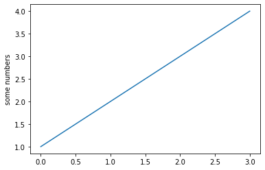

```python
list1 = [1,2,3,4]
plt.plot(list1)
plt.ylabel('some numbers')
# because we have written %matplotlib inline
# we don't need to write plt.show() every time
# but you could add it as well
plt.show()
```

**PRACTICE: plt.plot also takes NumPy ndarrays as data. Define an NumPy ndarray and plot it!**

You may be wondering why the x-axis ranges from 0 - 3 and the y-axis from 1 - 4. If you provide a single list or array to plot, matplotlib assumes it is a sequence of y values, and automatically generates the x values for you. Since python ranges start with 0, the default x vector has the same length as y but starts with 0. Hence the x data are [0, 1, 2, 3].

### Histogram

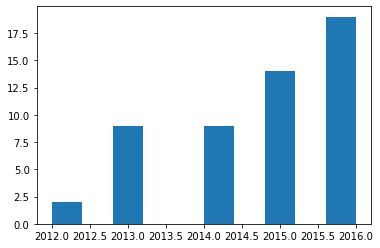

```python
# histogram
plt.hist(cars["Year"])
plt.show()
```

However, histogram is commonly used to visualize the distribution of a continuous variable.

In this case, since Year is a categorical variable, bar plot is more appropriate.

### Bar Plot

```python
cars["Year"].value_counts()
# left column is index
# right column is values
```

```
2016    19
2015    14
2014     9
2013     9
2012     2
Name: Year, dtype: int64
```

```python
# using bar plot for category variables
year = cars["Year"].value_counts().index
print(year)
values = cars["Year"].value_counts().values
print(values)
```

```
Int64Index([2016, 2015, 2014, 2013, 2012], dtype='int64')
[19 14  9  9  2]
```

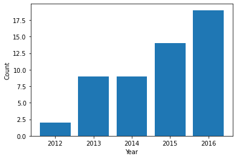

```python
# bar plots takes in 2 arguments
plt.bar(year, values)
plt.xlabel("Year")
plt.ylabel("Count")
```

### Pie chart

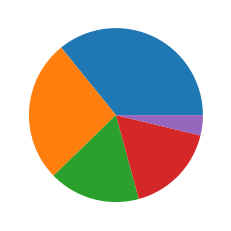

```python
fig1 = plt.pie(values)
plt.show()
```

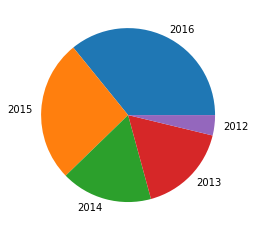

```python
# customize labels
mylabels = year
# send argument into plt.pie()
plt.pie(values, labels = mylabels)
plt.show()
```

Colors are customizable as well, and you could do it via its [name or hex values](https://www.webucator.com/article/python-color-constants-module/).

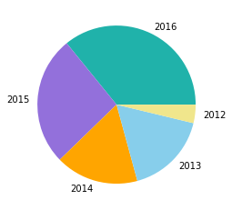

```python
# be as creative as you want, but the goal is to increase readability

# you can create list with color names,
mycolors_names = ['lightseagreen', 'mediumpurple', 'orange', 'skyblue', 'khaki']
# or create list with their corresponding hex codes
mycolors_hex = ['#20B2AA','#9370DB','#FFA500','#87CEEB','#F0E68C']
# send argument into plt.pie()
plt.pie(values, labels = mylabels, colors = mycolors_names)
plt.show()
```

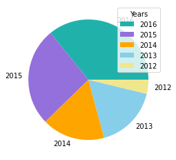

```python
# add legend with plt.legend(title = "")
plt.pie(values, labels = mylabels, colors = mycolors_names)
plt.legend(title = 'Years')
```

More on pie chart customization: [click here](https://www.w3schools.com/python/matplotlib_pie_charts.asp)

### Subplots

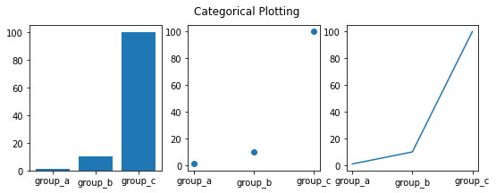

```python
# Sometimes, you want to compare different plots
# We do that by creating subplots
names = ['group_a', 'group_b', 'group_c']
values = [1, 10, 100]

plt.figure(figsize = (9, 3))
#plt.figure(figsize = (12, 3))

plt.subplot(1,3,1)
plt.bar(names, values)

plt.subplot(1,3,2)
plt.scatter(names, values)

plt.subplot(1,3,3)
plt.plot(names, values)

plt.suptitle('Categorical Plotting')
```

### Multiple variables

```python
# groupby function
df = cars[["Brands", "Size", "(kw)"]].groupby(["Brands", "Size"]).mean()
df
```

| Brands | Size | (kw) |
| --- | --- | --- |
| BMW | SUBCOMPACT | 125.000000 |
| CHEVROLET | SUBCOMPACT | 104.000000 |
| FORD | COMPACT | 107.000000 |
| KIA | STATION WAGON - SMALL | 81.000000 |
| MITSUBISHI | SUBCOMPACT | 49.000000 |
| NISSAN | MID-SIZE | 80.000000 |
| SMART | TWO-SEATER | 35.000000 |
| TESLA | FULL-SIZE | 332.952381 |
|  | SUV - STANDARD | 477.000000 |

### More interesting visualization websites

- https://ft-interactive.github.io/visual-vocabulary/
- https://datavizcatalogue.com/methods/nightingale_rose_chart.html
- http://visualizationuniverse.com/charts/?sortBy=volume&sortDir=asc

## Summary about Data Types

1. [Workshop 09-10 : Intro to Python](https://drive.google.com/drive/folders/1bXZ06fr-KU5TFJwSw2YHN6Dj_amkkPFl?usp=sharing)

| Basic Data Types | Example | Meaning/ Usage |
| --- | --- | --- |
| Integer (int) | 1, 2, 3 | Integer numbers |
| String (str) | "apple" | Text |
| Float (float) | 5.55 | Floating/ decimal point numbers |
| Boolean (bool) | True, False | True/False (Boolean) values |

1. [Workshop 09-17 : Intro to Data Structures](https://drive.google.com/drive/folders/1FKkSi279uQQFWFTOpG2n5EVTrBZQkGcO?usp=sharing)

| Collection Data Types | Example | Properties |
| --- | --- | --- |
| List (list) | ["apple", "orange", 5] | Changeable, Ordered, Duplicate allowed |
| Tuple (tuple) | ("apple", "orange", 5) | Unchangeable, Ordered, Duplicate allowed |
| Set (set) | {"apple", "orange", 5} | Unchangeable, Unordered, No duplicates |
| Dictionary (dict) | {"apple": 5, "orange": 10} | Key:Value pairs, Unchangeable, Unordered, No duplicates |

1. [Workshop 09-24 : Intro to Data Analysis with Python](https://drive.google.com/drive/folders/1waNdrV_4YAEm9ct8g_eDP15myejpn0Hp?usp=sharing)

| Pandas/ NumPy dtype | Corresponding Python type | Usage |
| --- | --- | --- |
| object | str | Text |
| int64 | int | Integer numbers |
| float64 | float | Floating point numbers |
| bool | bool | True/False (Boolean) values |
| datetime64 (only Pandas) | NA | Date and time values |
| category (only Pandas) | NA | Finite list of text values |

**When to use lists/ NumPy ndarrays/ Pandas DataFrame?**

- Lists: Flexible, convenient
- NumPy ndarrays: Designed for high performance in scientific computations. Good choice for high-dimensional data.
- Pandas DataFrame: Builds on ndarrays, preserves high performance. Good choice for tabular data with column index and row index (could be textual label or numeric).

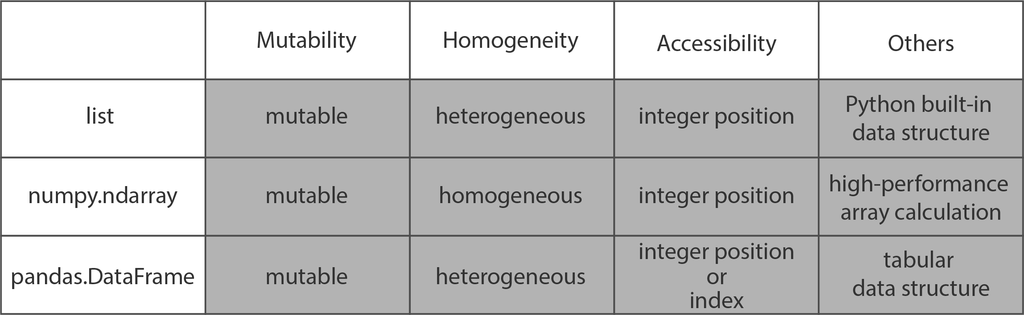

## Exercise

Explore more datasets in the [drive](https://drive.google.com/drive/folders/1waNdrV_4YAEm9ct8g_eDP15myejpn0Hp?usp=sharing).

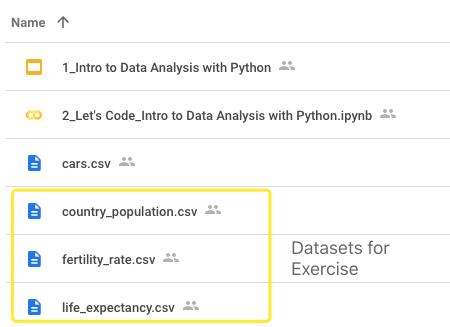

Tasks can include:

- Read/ write datasets
- Inspect data attributes
- Get certain columns for analysis
- Inspect/ clean up missing values
- EDA (Exploratory Data Analysis)
- Plotting with Matplotlib
- ...

If you need help with any material in this notebook, please contact NYU Shanghai Library at shanghai.library@nyu.edu

**Ending credits**

Tutorial framework:

https://www.w3schools.com/python/default.asp

Images:

https://towardsdatascience.com/python-list-numpy-and-pandas-3a32f1aee948

https://predictivehacks.com/tips-about-numpy-arrays/

Modified and organized by: Pamela Pan, Jie Chen